# Analysis

William Graif

7/11/2020

```r
q1 = read.csv("student-mat[1].csv", sep=";", header=TRUE)
q2 = read.csv("student-por[1].csv", sep=";", header=TRUE)
q3 = inner_join(q1,q2,by=c("school","sex","age","address","famsize","Pstatus","Medu","Fedu","Mjob","Fjob","reason","nursery","internet"))
#reads in the csv's and merges them

num.cols <- c("Medu", "Fedu", "famrel.x", "G3.x", "G3.y")
q3[num.cols] <- sapply(q3[num.cols], as.numeric)
#makes numeric
q3$G3.avg <- (q3$G3.x + q3$G3.y / 2)
#takes averages
```

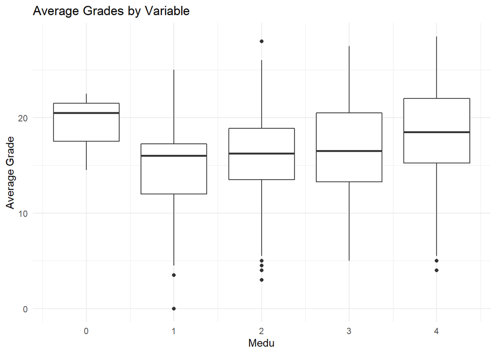

```
##
## [[2]]
##
##
##  Medu       Mean   Number   Median   Standard_Deviation
## -----  ---------  -------  -------  -------------------
##     0   19.16667        3    20.50             4.163332
##     1   14.34314       51    16.00             5.651097
##     2   15.62755       98    16.25             5.358446
##     3   16.63158       95    16.50             5.599302
##     4   18.20741      135    18.50             5.211707
##
## [[3]]
```

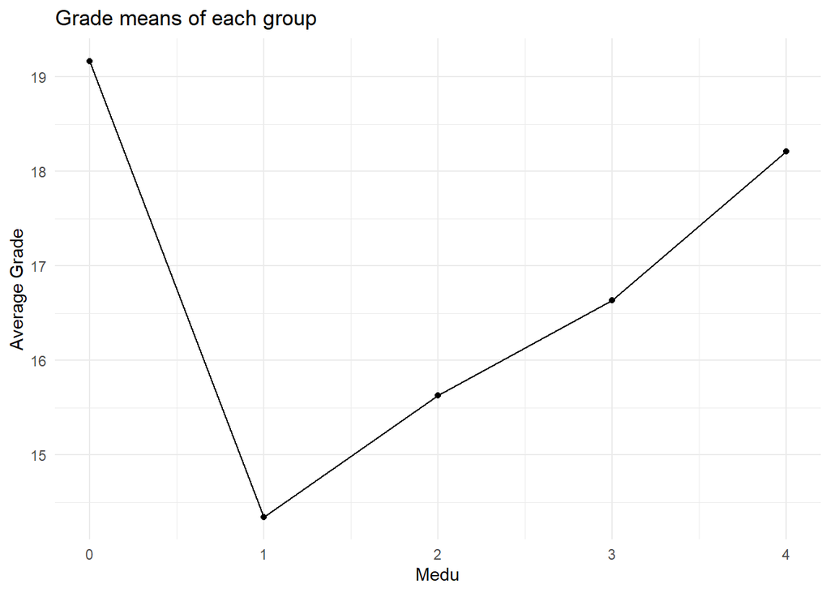

```r
summary2 <- function(col3) {
#function takes in a column name
plot2 <- ggplot(q3, mapping = aes(x=q3[[col3]], y=G3.avg, group=q3[[col3]])) +
  geom_boxplot() +
  labs(x=col3, y="Average Grade", title="Average Grades by Variable")
#making a boxplot for the column

df2<-q3 %>%
  group_by(q3[[col3]]) %>%
  summarize(Mean = mean(G3.avg), Number = n(), Median = median(G3.avg), Standard_Deviation = sd(G3.avg))
#storing a dataframe for the column with summary stats for it
colnames(df2)[1] <- col3
#renaming


if(typeof(q3[[col3]]) == "double") {
  #make a scatterplot for numeric columns
plot3 <- ggplot(df2, aes(x=df2[[col3]], y=Mean)) +
  geom_line() +
  geom_point() +
  labs(x=col3, y="Average Grade", title="Grade means of each group")


return(list(plot2, knitr::kable(df2), plot3))
#numeric columns return the boxplot, the dataframe, and the scatterplot
}

else {
  return(list(plot2, knitr::kable(df2)))
  #non-numeric columns return the boxplot and the dataframe
}

}

summary2("Medu")
```

We can see here that aside from the outlier of Mother’s Educational Level (MEDU) of 0 which has just three observations, there is a clear and consistent increasing trend between MEDU and average grades, of about 1 to 1.5 points on the 30-point scale per educational level.

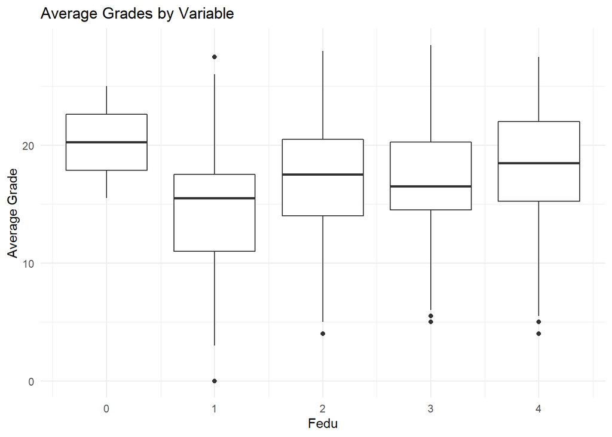

```
##
## [[2]]
##
##
##  Fedu       Mean   Number   Median   Standard_Deviation
## -----  ---------  -------  -------  -------------------
##     0   20.25000        2    20.25             6.717514
##     1   14.40260       77    15.50             6.027917
##     2   16.82857      105    17.50             5.345662
##     3   17.05556       99    16.50             4.869149
##     4   17.71212       99    18.50             5.602064
##
## [[3]]
```

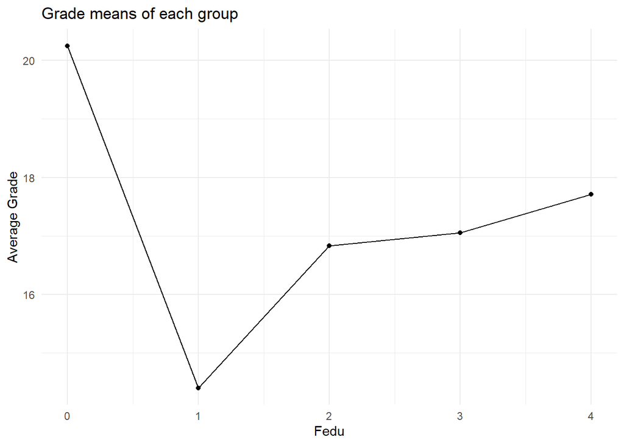

```r
summary2("Fedu")
```

Also ignoring the FEDU = 0 of just two observations, we notice a jump from 14.4 to 16.8 from FEDU = 1 to 2, before it rather levels out.

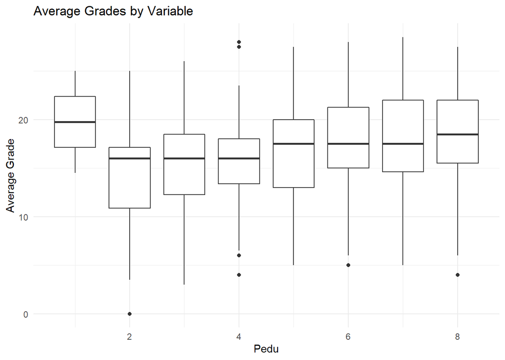

```
##
## [[2]]
##
##
##  Pedu       Mean   Number   Median   Standard_Deviation
## -----  ---------  -------  -------  -------------------
##     1   19.75000        2    19.75             7.424621
##     2   13.93056       36    16.00             6.101701
##     3   14.92308       39    16.00             5.696881
##     4   15.72794       68    16.00             5.026374
##     5   16.70732       41    17.50             5.692073
##     6   17.70635       63    17.50             4.796365
##     7   17.57759       58    17.50             5.848078
##     8   17.94667       75    18.50             5.278445
##
## [[3]]
```

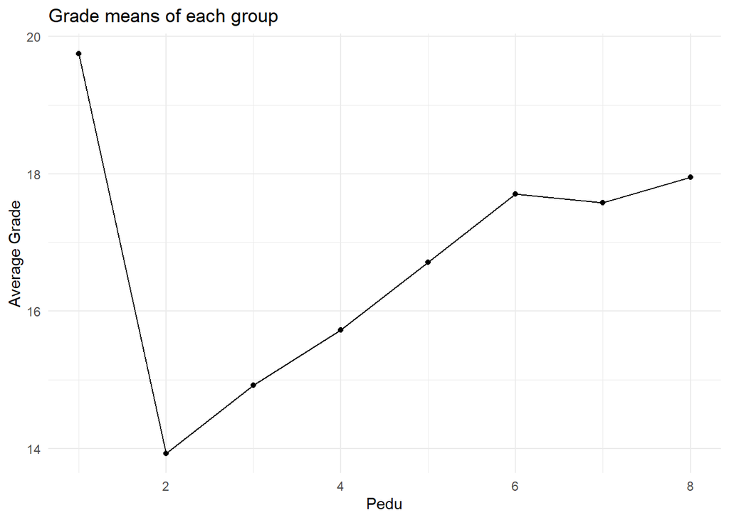

```r
q3$Pedu <- q3$Fedu + q3$Medu
#creates the new variable of the sum of Father and Mother educational attainment
summary2("Pedu")
```

“famrel” measures the quality of the student’s self-reported relationship with their family, on a numerical 1-5 scale. There appears to be a small trend between this variable and higher grades.

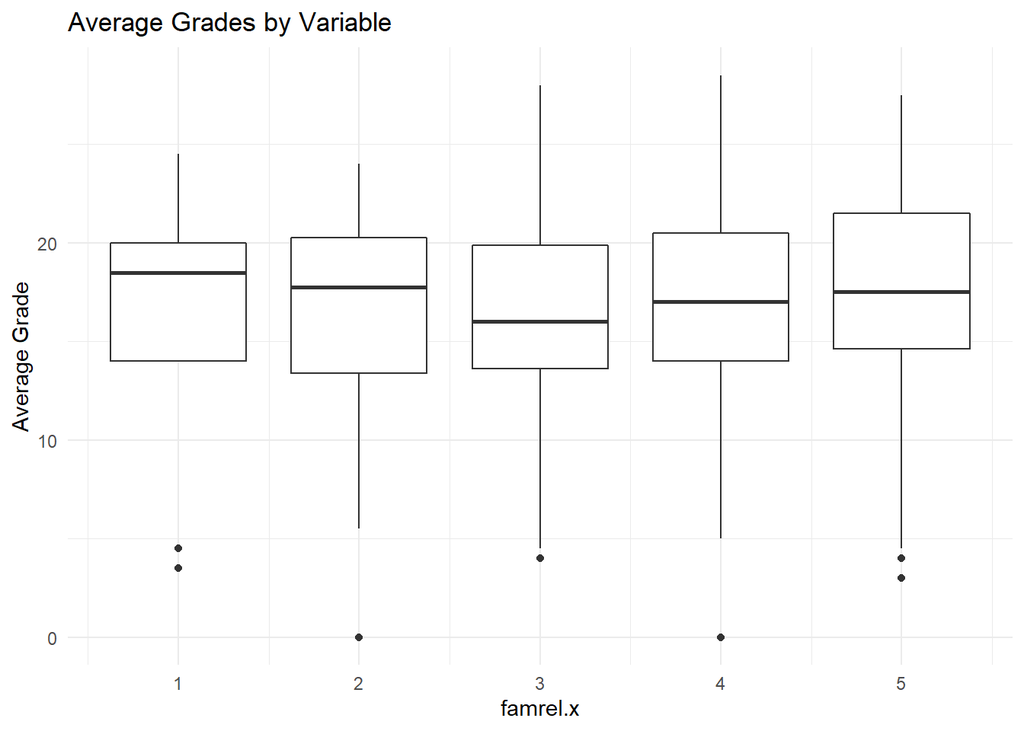

```
##
## [[2]]
##
##
##  famrel.x       Mean   Number   Median   Standard_Deviation
## ---------  ---------  -------  -------  -------------------
##         1   15.77778        9    18.50             7.220245
##         2   15.77778       18    17.75             6.494845
##         3   16.14394       66    16.00             5.529477
##         4   16.68852      183    17.00             5.261432
##         5   17.10377      106    17.50             5.777096
##
## [[3]]
```

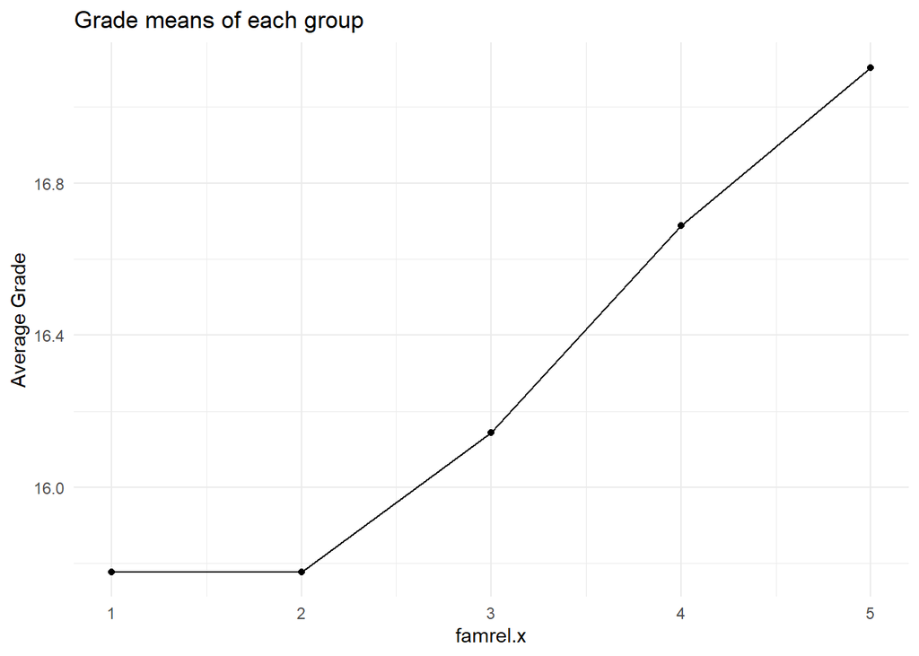

```r
summary2("famrel.x")
```

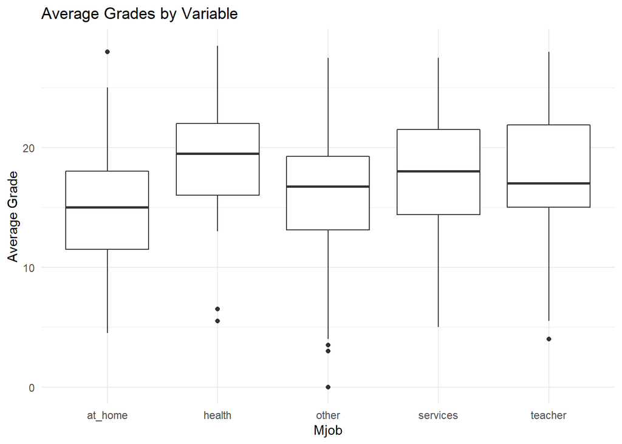

```
##
## [[2]]
##
##
## Mjob            Mean   Number   Median   Standard_Deviation
## ---------  ---------  -------  -------  -------------------
## at_home     15.00943       53    15.00             5.424739
## health      18.87879       33    19.50             5.001610
## other       15.71014      138    16.75             5.558190
## services    17.64062       96    18.00             5.471314
## teacher     17.39516       62    17.00             5.370790
```

```r
summary2("Mjob")
```

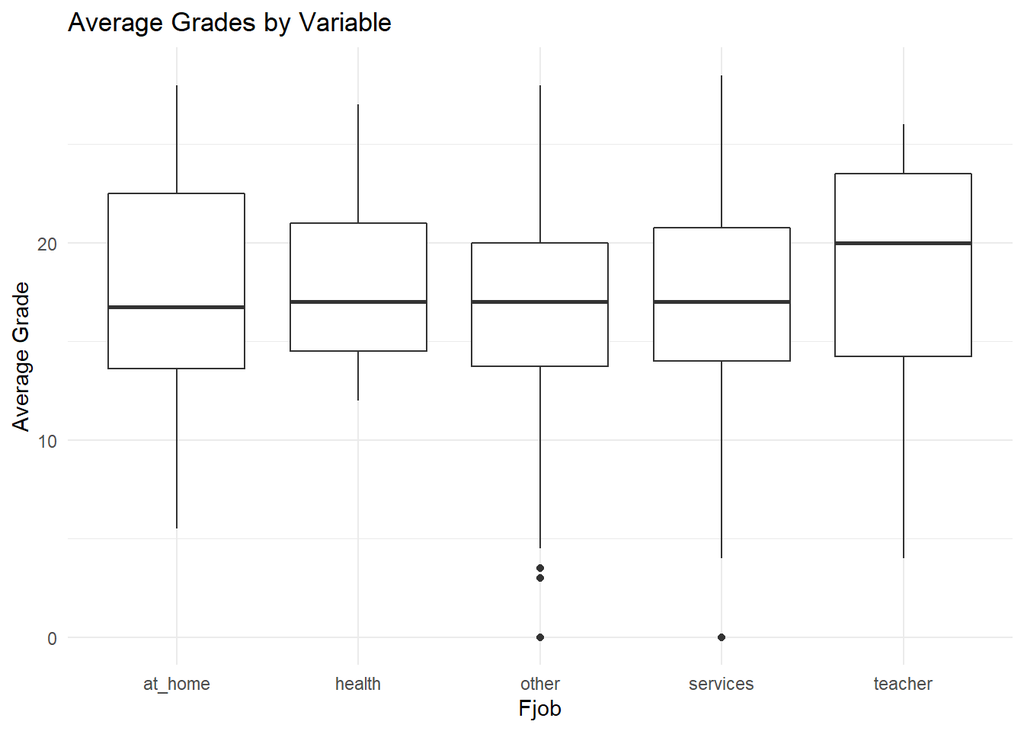

```
##
## [[2]]
##
##
## Fjob            Mean   Number   Median   Standard_Deviation
## ---------  ---------  -------  -------  -------------------
## at_home     16.59375       16    16.75             6.494148
## health      17.97059       17    17.00             4.273723
## other       16.37204      211    17.00             5.382752
## services    16.49533      107    17.00             5.547180
## teacher     18.32258       31    20.00             6.626397
```

```r
summary2("Fjob")
```

Some rather surprising phenomenon below. It appears that whether or not a student receives family educational support has no bearing on their aveage grades, with 16.8 for those who answered “no” vs 16.6 for those who answered “yes.” As well, students with parents who live apart average 17.8, which is actually *higher* than the 16.5 average of students with parents that live together.

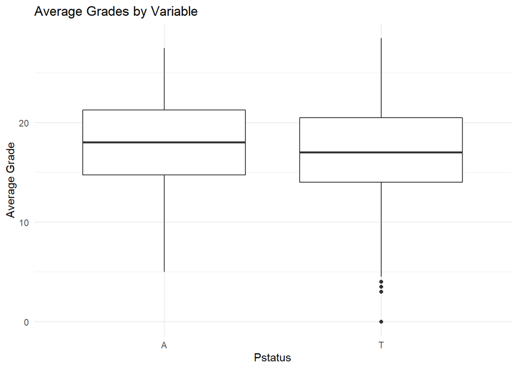

```
##
## [[2]]
##
##
## Pstatus        Mean   Number   Median   Standard_Deviation
## --------  ---------  -------  -------  -------------------
## A          17.76316       38       18             5.151406
## T          16.52180      344       17             5.582429
```

```r
summary2("Pstatus")
```

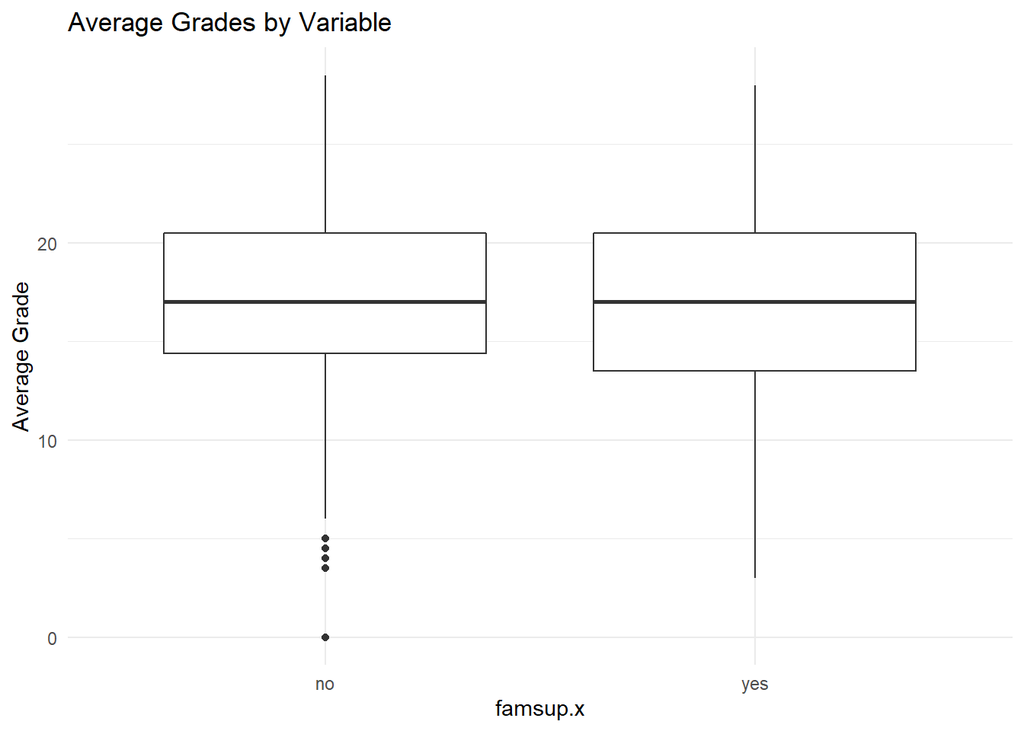

```
##
## [[2]]
##
##
## famsup.x        Mean   Number   Median   Standard_Deviation
## ---------  ---------  -------  -------  -------------------
## no          16.78472      144       17             5.803198
## yes         16.56092      238       17             5.397048
```

```r
summary2("famsup.x")
```

Here we can observe some interaction between Parental Status and the above-defined PEDU variable in terms of the effect on the response variable of average grade. The students with parents that are “together” exhibit a clear increasing trend in their grades as PEDU increases (save for PEDU=1 with merely two observations), before levelling out at PEDU=6. The students with “apart” parental statuses, however, do not have any trend with PEDU, as we literally see alternating increases and decreases in their grades for each one-level increase in PEDU. Granted, this could be due to the smaller sample sizes within the “apart” subset.

```r
knitr::kable(q3 %>%
  group_by(Pstatus, Pedu) %>%
  summarize(Mean = mean(G3.avg), Number = n(), Median = median(G3.avg), Standard_Deviation = sd(G3.avg)) )
```

| Pstatus | Pedu | Mean | Number | Median | Standard_Deviation |
| --- | --- | --- | --- | --- | --- |
| A | 3 | 17.16667 | 3 | 16.00 | 2.466441 |
| A | 4 | 16.00000 | 4 | 16.75 | 7.449832 |
| A | 5 | 19.00000 | 7 | 18.00 | 5.522680 |
| A | 6 | 14.75000 | 6 | 16.00 | 5.067050 |
| A | 7 | 19.61111 | 9 | 18.00 | 4.567397 |
| A | 8 | 17.94444 | 9 | 18.00 | 5.186789 |
| T | 1 | 19.75000 | 2 | 19.75 | 7.424621 |
| T | 2 | 13.93056 | 36 | 16.00 | 6.101701 |
| T | 3 | 14.73611 | 36 | 15.50 | 5.866961 |
| T | 4 | 15.71094 | 64 | 16.00 | 4.921450 |
| T | 5 | 16.23529 | 34 | 17.25 | 5.690549 |
| T | 6 | 18.01754 | 57 | 18.00 | 4.705586 |
| T | 7 | 17.20408 | 49 | 17.50 | 6.018131 |
| T | 8 | 17.94697 | 66 | 18.50 | 5.329980 |

```r
#looking at PEDU by Parental Status and the summary statistics of that for GPA; this is a tidy formatted table
```

This shows that there is an interaction between sex and parental status in terms of their effects on GPA. The 21 Females with parents who live apart have an average of 15.9 – which might make sense, as that is just under the overall average – whereas the 17 males with parents who live apart have an average of 20.1! This is in spite of no major difference between the sexes overall in terms of grades.

```r
knitr::kable(q3 %>%
  group_by(sex, Pstatus) %>%
  summarize(Mean = mean(G3.avg), Number = n(), Median = median(G3.avg), Standard_Deviation = sd(G3.avg)) )
```

| sex | Pstatus | Mean | Number | Median | Standard_Deviation |
| --- | --- | --- | --- | --- | --- |
| F | A | 15.88095 | 21 | 16.5 | 4.535705 |
| F | T | 16.44068 | 177 | 16.5 | 5.517600 |
| M | A | 20.08824 | 17 | 18.0 | 5.025669 |
| M | T | 16.60778 | 167 | 17.0 | 5.665665 |

```r
#similar idea as above
```

# REPORT:

I cleaned the data a little bit, as some obviously numeric columns were not actually coded as numeric after the merge, so I set them as such. I then wrote a very long function to provide insight into my variables of interest.

Interestingly, whether or not a student received family support had no bearing on the student’s grades, and students with aprents living apart actually had slightly higher grades than their peers with parents living together. However, when we break this up by sex, we observe an interesting phenomenon. Female students with parents living apart score just under, a hair under the overall average, whereas male students with parents living apart score over 20 on average! Overall, however, the difference in grades between males and females is indescernible. Especially as this is disparate impact, perhaps it should be a public policy goal to ensure that female students with separated parents are still receiving the necessary support to succeed. In general, however, it is clear that the biggest causes of grade increases that I have identified include the level of educational attainment of one’s parents (although particularly for fathers, the importance of this can level off) as well as the type of job your parents have. These two variables are likely correlated, in fact. It is surprising that the level of support and the level of relationship with one’s family were not more important in predicting grades. Perhaps this points to limitations in my data. This is only two public schools in Portugal, so it is difficult to say how generalizable it is to everyone. Furthermore, perhaps the sample size was an issue, as you can note in the dataframes that the standard deviations are too large to claim statistical significance in almost all cases. As well, maybe the original data collection methods itself were not perfect.

Data can be found here: [link](https://archive.ics.uci.edu/ml/datasets/student+performance)